# Pleural cfDNA Screening Array

DNAm Data Release Summary

Paul Yousefi

19 June 2026

# Overview

This document summarises the versioned DNAm data release for the pleural cfDNA screening array study (project M2644). It links array locations to the released samplesheet, constructs a combined phenotype table annotating each sample with sex, malignancy status, plate, and QC-pass/fail status, and produces a stratified descriptive table to characterise the study population.

# Sample Characteristics of QC Pass/Fail Samples

Of 335 samples, 28 (8.4%) failed QC and were excluded from the clean release. The table below compares the distribution of malignancy status, sex, plate, and slide between samples that passed and failed QC, giving an overview of the study population and highlighting any systematic differences between included and excluded samples.

Sample characteristics stratified by QC pass/fail status

|  | level | 0 | 1 | p | test |
| --- | --- | --- | --- | --- | --- |
| n |  | 28 | 307 |  |  |
| age (mean (SD)) |  | 71.57 (12.44) | 71.01 (12.90) | 0.825 |  |
| malignant (%) | 0 | 11 (39.3) | 136 (44.3) | 0.754 |  |
|  | 1 | 17 (60.7) | 171 (55.7) |  |  |
| female (%) | 0 | 11 (39.3) | 200 (65.1) | 0.012 |  |
|  | 1 | 17 (60.7) | 107 (34.9) |  |  |
| plate (%) | 1 | 8 (28.6) | 88 (28.7) | 0.049 |  |
|  | 2 | 13 (46.4) | 83 (27.0) |  |  |
|  | 3 | 7 (25.0) | 88 (28.7) |  |  |
|  | 4 | 0 (0.0) | 48 (15.6) |  |  |
| slide (%) | 208661850039 | 1 (3.6) | 47 (15.3) | 0.008 |  |
|  | 208661850041 | 4 (14.3) | 44 (14.3) |  |  |
|  | 208661850042 | 5 (17.9) | 42 (13.7) |  |  |
|  | 208661850043 | 2 (7.1) | 46 (15.0) |  |  |
|  | 208661850044 | 9 (32.1) | 39 (12.7) |  |  |
|  | 208661850045 | 7 (25.0) | 41 (13.4) |  |  |
|  | 208788350010 | 0 (0.0) | 48 (15.6) |  |  |

# CpG Site QC

Of 284,317 CpG sites on the assay, 48,216 (17%) did not pass QC and are absent from the released beta-value matrix, leaving 236,101 sites available for analysis.

## Sample Correlation Structure

To assess the overall similarity between samples, pairwise Pearson correlations were computed across all 236,101 post-QC CpG sites. The histogram below shows the distribution of all 47,278 upper-triangle sample-pair correlations, with a density overlay. A tight, high-correlation distribution indicates consistent DNAm profiles across samples, while low-correlation outliers may reflect technical or biological heterogeneity.

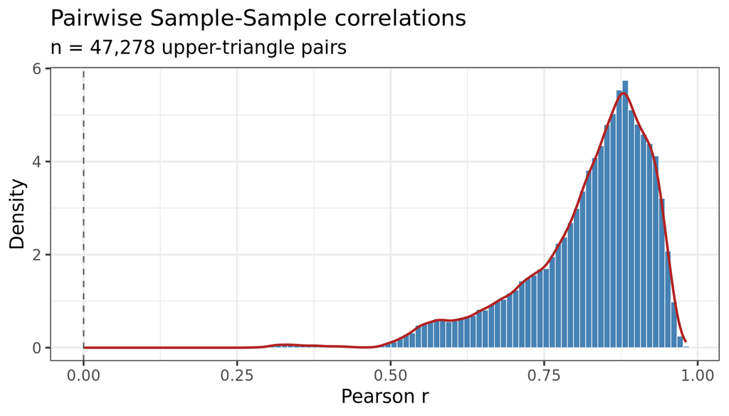

The plot below shows the distribution of per-sample median correlations — i.e. for each sample, the median of its pairwise Pearson *r* with all other samples. Samples with an unusually low median correlation may be outliers warranting further investigation.

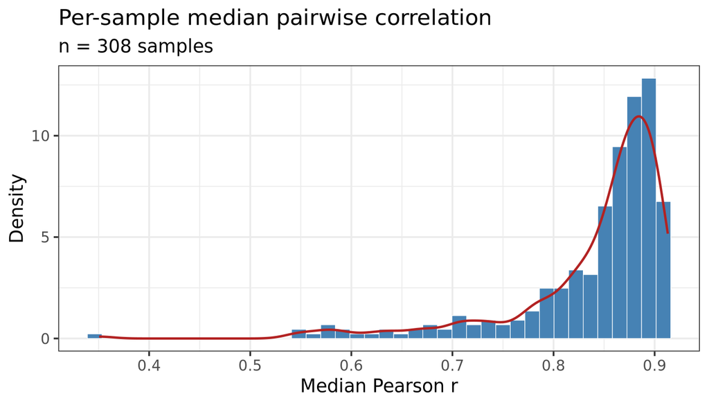